# ISLR: Lab Linear Regression

by* [*Michael L. Bernauer*](http://mlbernauer.bitbucket.org/)

03/13/2015

## Libraries

Librarires, or R-packages are loaded into the R environmen using `library()` or `require()`

```r
require(ISLR)
require(MASS)
require(GGally)
```

```r
require(ggplot2)
```

## Simple linear regression

In this example we will explor th `Boston` dataset contained within the `MASS` package. We will seek to predict the *medv* (median house value, in $1000) using *rm* (average house room number), `age` (average age of houses in neighborhood) and `lstat` (percentage of households with low socioeconomic status).

```r
# First lets explore that Boston dataset
dim(Boston)
```

```
## [1] 506  14
```

```r
names(Boston)
```

```
##  [1] "crim"    "zn"      "indus"   "chas"    "nox"     "rm"      "age"
##  [8] "dis"     "rad"     "tax"     "ptratio" "black"   "lstat"   "medv"
```

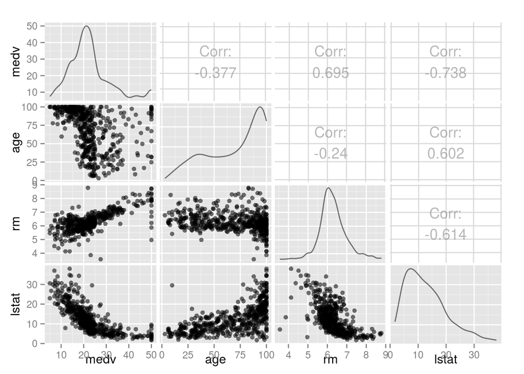

```r
#summary(Boston)

# Plot scatterplo matrix to explore relationships/correlations
ggpairs(Boston[,c("medv", "age", "rm", "lstat")], alpha=0.1)
```

From the scatterplot matrix we can see there is an inverse relationship between `medv` and `lstat`; that is, when the median value of houses in the neighborhood increases, there is a corresponding drop in the percentage of households with low socioeconomic status.

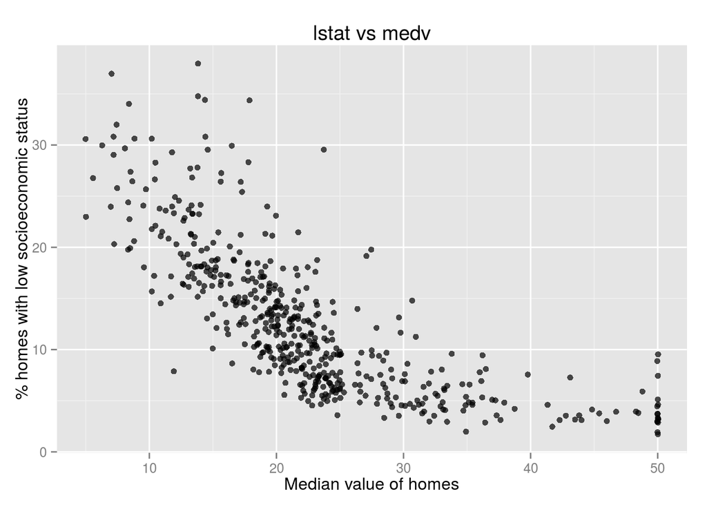

```r
ggplot(Boston, aes(x=medv, y=lstat)) +
  geom_jitter(alpha=0.7) +
  labs(title="lstat vs medv", x="Median value of homes", y="% homes with low socioeconomic status")
```

From the scatterplot matrix we can also see the positive relationship between `medv` and `rm`

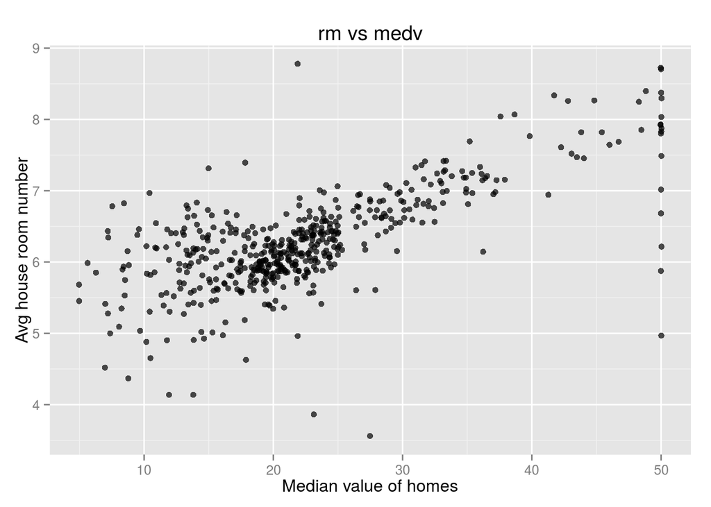

```r
ggplot(Boston, aes(x=medv, y=rm)) +
  geom_jitter(alpha=0.7) +
  labs(title="rm vs medv", x="Median value of homes", y="Avg house room number")
```

The correlation between `medv` and `age` is less apparent however, there does seem to be a negative relation ship. It appears as if the median value of the house decreases slightly with age.

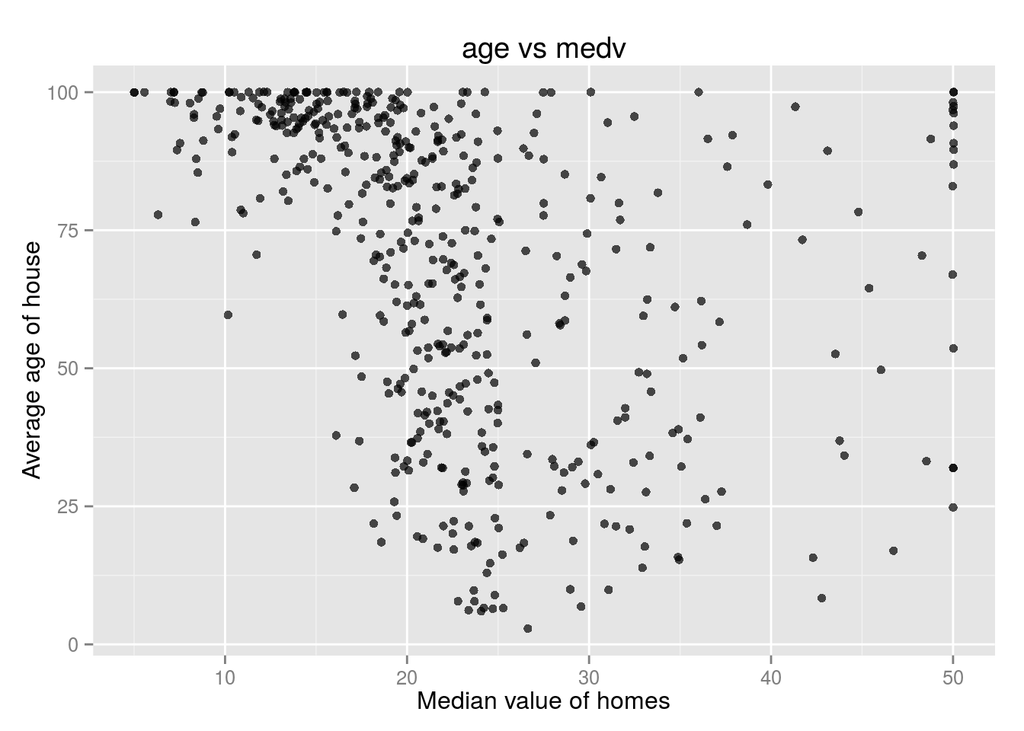

```r
ggplot(Boston, aes(x=medv, y=age)) +
  geom_jitter(alpha=0.7) +
  labs(title="age vs medv", x="Median value of homes", y="Average age of house")
```

## Linear regression

```r
fit <- lm(medv ~ lstat, data=Boston)
summary(fit)
```

```
##
## Call:
## lm(formula = medv ~ lstat, data = Boston)
##
## Residuals:
##     Min      1Q  Median      3Q     Max
## -15.168  -3.990  -1.318   2.034  24.500
##
## Coefficients:
##             Estimate Std. Error t value Pr(>|t|)
## (Intercept) 34.55384    0.56263   61.41   <2e-16 ***
## lstat       -0.95005    0.03873  -24.53   <2e-16 ***
## ---
## Signif. codes:  0 '***' 0.001 '**' 0.01 '*' 0.05 '.' 0.1 ' ' 1
##
## Residual standard error: 6.216 on 504 degrees of freedom
## Multiple R-squared:  0.5441, Adjusted R-squared:  0.5432
## F-statistic: 601.6 on 1 and 504 DF,  p-value: < 2.2e-16
```

```r
confint(fit)
```

```
##                 2.5 %     97.5 %
## (Intercept) 33.448457 35.6592247
## lstat       -1.026148 -0.8739505
```

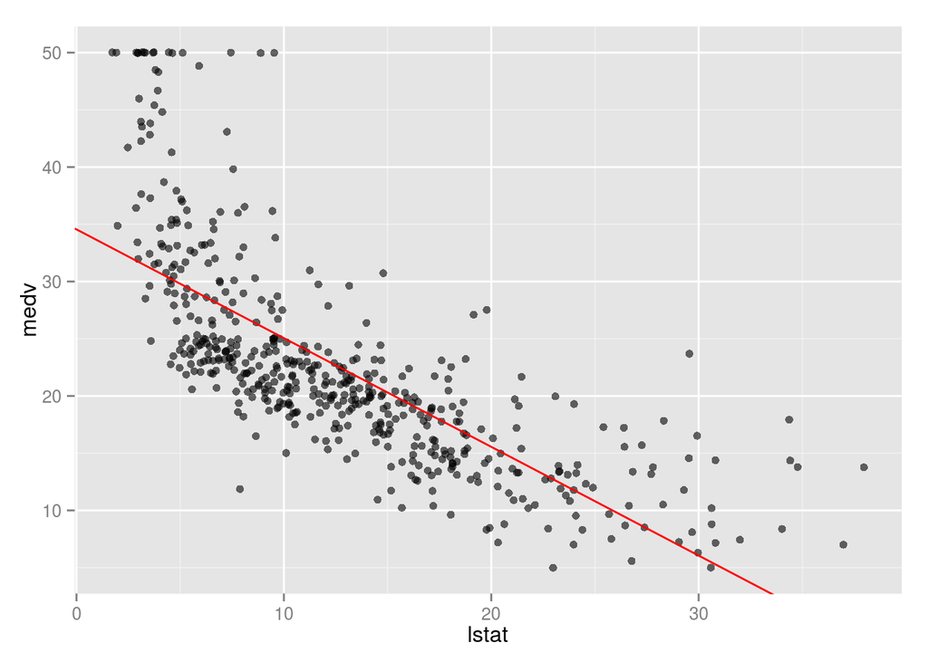

```r
# Check to see how the model fits
intercept <- coef(fit)[1]
slope <- coef(fit)[2]
ggplot(Boston, aes(x=lstat, y=medv)) +
  geom_point(position=position_jitter(), alpha=0.6) +
  geom_abline(intercept=intercept, slope=slope, col="red")
```

## Checking assumptions

We can check assumptions about our model such as equal variance by plotting the residuals by calling the `plot()` method. This will also tell us if our data is non-linear. If the data is non-linear than the residuals will exhibit some sort of pattern when plotted.

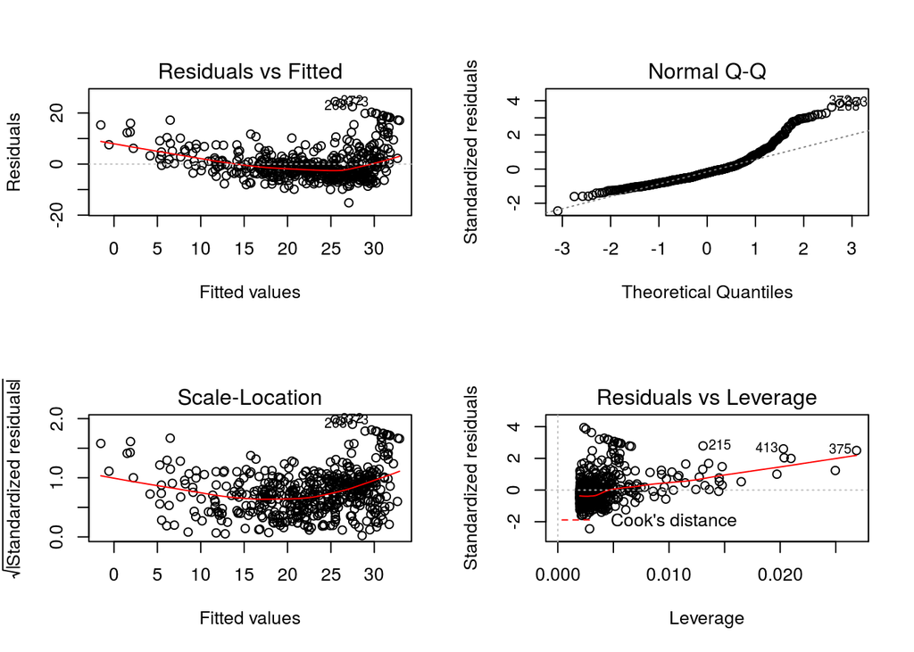

```r
par(mfrow=c(2,2))
plot(fit)
```

## Making predicitons

```r
# Create a dataframe containing houses with various room sizes
new_data <- data.frame(lstat=c(8, 9, 10, 15, 20, 30))

# Return predictions with confidence intervals
predict(fit, new_data, interval="confidence")
```

```
##        fit       lwr       upr
## 1 26.95345 26.305287 27.601605
## 2 26.00340 25.393471 26.613322
## 3 25.05335 24.474132 25.632563
## 4 20.30310 19.731588 20.874613
## 5 15.55285 14.773550 16.332157
## 6  6.05236  4.625004  7.479716
```

```r
# Return predictions with prediciton intervals
predict(fit, new_data, interval="prediction")
```

```
##        fit       lwr      upr
## 1 26.95345 14.724265 39.18263
## 2 26.00340 13.776182 38.23061
## 3 25.05335 12.827626 37.27907
## 4 20.30310  8.077742 32.52846
## 5 15.55285  3.316021 27.78969
## 6  6.05236 -6.242765 18.34749
```

## Multiple linear regression

```r
fit <- lm(medv ~ lstat + age, data=Boston)
summary(fit)
```

```
##
## Call:
## lm(formula = medv ~ lstat + age, data = Boston)
##
## Residuals:
##     Min      1Q  Median      3Q     Max
## -15.981  -3.978  -1.283   1.968  23.158
##
## Coefficients:
##             Estimate Std. Error t value Pr(>|t|)
## (Intercept) 33.22276    0.73085  45.458  < 2e-16 ***
## lstat       -1.03207    0.04819 -21.416  < 2e-16 ***
## age          0.03454    0.01223   2.826  0.00491 **
## ---
## Signif. codes:  0 '***' 0.001 '**' 0.01 '*' 0.05 '.' 0.1 ' ' 1
##
## Residual standard error: 6.173 on 503 degrees of freedom
## Multiple R-squared:  0.5513, Adjusted R-squared:  0.5495
## F-statistic:   309 on 2 and 503 DF,  p-value: < 2.2e-16
```

We can create a model with all 13 variables in `Boston` dataset

```r
# We can use . to tell the lm function to use all variables
fit <- lm(medv ~ . , data=Boston)
summary(fit)
```

```
##
## Call:
## lm(formula = medv ~ ., data = Boston)
##
## Residuals:
##     Min      1Q  Median      3Q     Max
## -15.595  -2.730  -0.518   1.777  26.199
##
## Coefficients:
##               Estimate Std. Error t value Pr(>|t|)
## (Intercept)  3.646e+01  5.103e+00   7.144 3.28e-12 ***
## crim        -1.080e-01  3.286e-02  -3.287 0.001087 **
## zn           4.642e-02  1.373e-02   3.382 0.000778 ***
## indus        2.056e-02  6.150e-02   0.334 0.738288
## chas         2.687e+00  8.616e-01   3.118 0.001925 **
## nox         -1.777e+01  3.820e+00  -4.651 4.25e-06 ***
## rm           3.810e+00  4.179e-01   9.116  < 2e-16 ***
## age          6.922e-04  1.321e-02   0.052 0.958229
## dis         -1.476e+00  1.995e-01  -7.398 6.01e-13 ***
## rad          3.060e-01  6.635e-02   4.613 5.07e-06 ***
## tax         -1.233e-02  3.760e-03  -3.280 0.001112 **
## ptratio     -9.527e-01  1.308e-01  -7.283 1.31e-12 ***
## black        9.312e-03  2.686e-03   3.467 0.000573 ***
## lstat       -5.248e-01  5.072e-02 -10.347  < 2e-16 ***
## ---
## Signif. codes:  0 '***' 0.001 '**' 0.01 '*' 0.05 '.' 0.1 ' ' 1
##
## Residual standard error: 4.745 on 492 degrees of freedom
## Multiple R-squared:  0.7406, Adjusted R-squared:  0.7338
## F-statistic: 108.1 on 13 and 492 DF,  p-value: < 2.2e-16
```

```r
fit_summary <- summary(fit)
fit_summary$r.sq
```

```
## [1] 0.7406427
```

```r
fit_summary$sigma
```

```
## [1] 4.745298
```

The `car` package can be used to compute the variance inflation factors

```r
library(car)
vif(fit)
```

```
##     crim       zn    indus     chas      nox       rm      age      dis
## 1.792192 2.298758 3.991596 1.073995 4.393720 1.933744 3.100826 3.955945
##      rad      tax  ptratio    black    lstat
## 7.484496 9.008554 1.799084 1.348521 2.941491
```

We can create a model using all but one of the variables

```r
# Create a new model with all variables except age
fit <- lm(medv ~ . -age, data=Boston)

# Update a model to include age
fit <- update(fit, ~ . + age, data=Boston)
summary(fit)
```

```
##
## Call:
## lm(formula = medv ~ crim + zn + indus + chas + nox + rm + dis +
##     rad + tax + ptratio + black + lstat + age, data = Boston)
##
## Residuals:
##     Min      1Q  Median      3Q     Max
## -15.595  -2.730  -0.518   1.777  26.199
##
## Coefficients:
##               Estimate Std. Error t value Pr(>|t|)
## (Intercept)  3.646e+01  5.103e+00   7.144 3.28e-12 ***
## crim        -1.080e-01  3.286e-02  -3.287 0.001087 **
## zn           4.642e-02  1.373e-02   3.382 0.000778 ***
## indus        2.056e-02  6.150e-02   0.334 0.738288
## chas         2.687e+00  8.616e-01   3.118 0.001925 **
## nox         -1.777e+01  3.820e+00  -4.651 4.25e-06 ***
## rm           3.810e+00  4.179e-01   9.116  < 2e-16 ***
## dis         -1.476e+00  1.995e-01  -7.398 6.01e-13 ***
## rad          3.060e-01  6.635e-02   4.613 5.07e-06 ***
## tax         -1.233e-02  3.760e-03  -3.280 0.001112 **
## ptratio     -9.527e-01  1.308e-01  -7.283 1.31e-12 ***
## black        9.312e-03  2.686e-03   3.467 0.000573 ***
## lstat       -5.248e-01  5.072e-02 -10.347  < 2e-16 ***
## age          6.922e-04  1.321e-02   0.052 0.958229
## ---
## Signif. codes:  0 '***' 0.001 '**' 0.01 '*' 0.05 '.' 0.1 ' ' 1
##
## Residual standard error: 4.745 on 492 degrees of freedom
## Multiple R-squared:  0.7406, Adjusted R-squared:  0.7338
## F-statistic: 108.1 on 13 and 492 DF,  p-value: < 2.2e-16
```

## Interaction terms

We can include interaction effects between variables by using `rm:lstat` which includes only the interaction in the model. However, if we use `rm*lstat` the notation will automatically include the individual variables in the model.

```r
fit <- lm(medv ~ age:rm, data=Boston)
fit2 <- lm(medv ~ age*rm, data=Boston)
summary(fit)
```

```
##
## Call:
## lm(formula = medv ~ age:rm, data = Boston)
##
## Residuals:
##     Min      1Q  Median      3Q     Max
## -16.335  -5.097  -1.917   2.595  31.089
##
## Coefficients:
##              Estimate Std. Error t value Pr(>|t|)
## (Intercept) 26.818720   1.058235  25.343  < 2e-16 ***
## age:rm      -0.010056   0.002297  -4.378 1.46e-05 ***
## ---
## Signif. codes:  0 '***' 0.001 '**' 0.01 '*' 0.05 '.' 0.1 ' ' 1
##
## Residual standard error: 9.036 on 504 degrees of freedom
## Multiple R-squared:  0.03663,    Adjusted R-squared:  0.03472
## F-statistic: 19.16 on 1 and 504 DF,  p-value: 1.459e-05
```

```r
summary(fit2)
```

```
##
## Call:
## lm(formula = medv ~ age * rm, data = Boston)
##
## Residuals:
##     Min      1Q  Median      3Q     Max
## -18.864  -3.059  -0.182   2.191  38.604
##
## Coefficients:
##              Estimate Std. Error t value Pr(>|t|)
## (Intercept) -59.59286    7.78687  -7.653 1.01e-13 ***
## age           0.38153    0.09673   3.944 9.15e-05 ***
## rm           13.74747    1.20186  11.438  < 2e-16 ***
## age:rm       -0.07141    0.01512  -4.722 3.03e-06 ***
## ---
## Signif. codes:  0 '***' 0.001 '**' 0.01 '*' 0.05 '.' 0.1 ' ' 1
##
## Residual standard error: 6.186 on 502 degrees of freedom
## Multiple R-squared:  0.5503, Adjusted R-squared:  0.5476
## F-statistic: 204.7 on 3 and 502 DF,  p-value: < 2.2e-16
```

## Non-linear transformations on variables

We’ve seen that there seems to be a non-linear relationship between `medv` and `lstat` we can fit a non-linear model to this by performing some sort of tranformation on the variables.

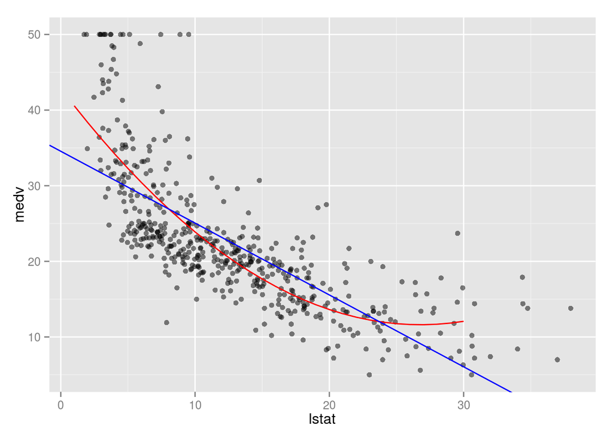

```r
quad_fit <- lm(medv ~ lstat + I(lstat^2), data=Boston)
linear_fit <- lm(medv ~ lstat, data=Boston)
predictions <- data.frame(pred=predict(quad_fit, data.frame(lstat=1:30)))
ggplot(Boston, aes(x=lstat, y=medv)) + geom_point(alpha=0.5) +
  geom_line(data=predictions, aes(x=1:dim(predictions)[1], y=pred), color="red") +
  geom_abline(intercept=intercept, slope=slope, color="blue")
```

The plot above shows the two different models; the linear model and the quadratic model it appears that the non-linear model fits the data better, however to test this more formally using `anova()`

```r
# Assess whether the null hypothesis is true, i.e. the two models are the same
anova(quad_fit, linear_fit)
```

```
## Analysis of Variance Table
##
## Model 1: medv ~ lstat + I(lstat^2)
## Model 2: medv ~ lstat
##   Res.Df   RSS Df Sum of Sq     F    Pr(>F)
## 1    503 15347
## 2    504 19472 -1   -4125.1 135.2 < 2.2e-16 ***
## ---
## Signif. codes:  0 '***' 0.001 '**' 0.01 '*' 0.05 '.' 0.1 ' ' 1
```

Lets inspect the residuals and leverage statistics for the new plot

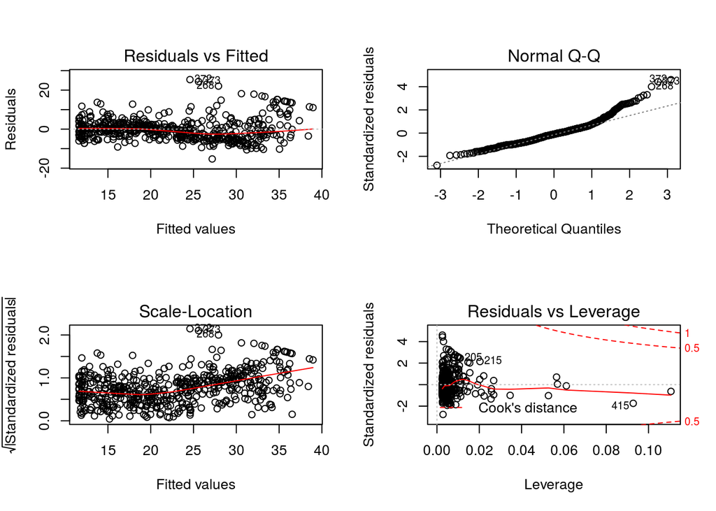

```r
par(mfrow=c(2,2))
plot(quad_fit)
```

Using the `poly()` function will include all lower-order polynomial terms up to the specified order.

```r
fit <- lm(medv ~ poly(lstat, 5), data=Boston)
summary(fit)
```

```
##
## Call:
## lm(formula = medv ~ poly(lstat, 5), data = Boston)
##
## Residuals:
##      Min       1Q   Median       3Q      Max
## -13.5433  -3.1039  -0.7052   2.0844  27.1153
##
## Coefficients:
##                  Estimate Std. Error t value Pr(>|t|)
## (Intercept)       22.5328     0.2318  97.197  < 2e-16 ***
## poly(lstat, 5)1 -152.4595     5.2148 -29.236  < 2e-16 ***
## poly(lstat, 5)2   64.2272     5.2148  12.316  < 2e-16 ***
## poly(lstat, 5)3  -27.0511     5.2148  -5.187 3.10e-07 ***
## poly(lstat, 5)4   25.4517     5.2148   4.881 1.42e-06 ***
## poly(lstat, 5)5  -19.2524     5.2148  -3.692 0.000247 ***
## ---
## Signif. codes:  0 '***' 0.001 '**' 0.01 '*' 0.05 '.' 0.1 ' ' 1
##
## Residual standard error: 5.215 on 500 degrees of freedom
## Multiple R-squared:  0.6817, Adjusted R-squared:  0.6785
## F-statistic: 214.2 on 5 and 500 DF,  p-value: < 2.2e-16
```

## Qualitative predictors

Qualtative variables can be used in regression models too, to see how R encodes these variables we can use the `contrasts()` function

```r
data(Carseats)
head(Carseats)
```

```
##   Sales CompPrice Income Advertising Population Price ShelveLoc Age
## 1  9.50       138     73          11        276   120       Bad  42
## 2 11.22       111     48          16        260    83      Good  65
## 3 10.06       113     35          10        269    80    Medium  59
## 4  7.40       117    100           4        466    97    Medium  55
## 5  4.15       141     64           3        340   128       Bad  38
## 6 10.81       124    113          13        501    72       Bad  78
##   Education Urban  US
## 1        17   Yes Yes
## 2        10   Yes Yes
## 3        12   Yes Yes
## 4        14   Yes Yes
## 5        13   Yes  No
## 6        16    No Yes
```

```r
contrasts(Carseats$ShelveLoc)
```

```
##        Good Medium
## Bad       0      0
## Good      1      0
## Medium    0      1
```

Now lets try to predict carseat sales, `Sales` using the features of `Carseats`. We will include interaction terms for `Income` and `Advertising` as well as `Price` and `Age`

```r
fit <- lm(Sales ~ . + Income:Advertising + Price:Age, data=Carseats)
summary(fit)
```

```
##
## Call:
## lm(formula = Sales ~ . + Income:Advertising + Price:Age, data = Carseats)
##
## Residuals:
##     Min      1Q  Median      3Q     Max
## -2.9208 -0.7503  0.0177  0.6754  3.3413
##
## Coefficients:
##                      Estimate Std. Error t value Pr(>|t|)
## (Intercept)         6.5755654  1.0087470   6.519 2.22e-10 ***
## CompPrice           0.0929371  0.0041183  22.567  < 2e-16 ***
## Income              0.0108940  0.0026044   4.183 3.57e-05 ***
## Advertising         0.0702462  0.0226091   3.107 0.002030 **
## Population          0.0001592  0.0003679   0.433 0.665330
## Price              -0.1008064  0.0074399 -13.549  < 2e-16 ***
## ShelveLocGood       4.8486762  0.1528378  31.724  < 2e-16 ***
## ShelveLocMedium     1.9532620  0.1257682  15.531  < 2e-16 ***
## Age                -0.0579466  0.0159506  -3.633 0.000318 ***
## Education          -0.0208525  0.0196131  -1.063 0.288361
## UrbanYes            0.1401597  0.1124019   1.247 0.213171
## USYes              -0.1575571  0.1489234  -1.058 0.290729
## Income:Advertising  0.0007510  0.0002784   2.698 0.007290 **
## Price:Age           0.0001068  0.0001333   0.801 0.423812
## ---
## Signif. codes:  0 '***' 0.001 '**' 0.01 '*' 0.05 '.' 0.1 ' ' 1
##
## Residual standard error: 1.011 on 386 degrees of freedom
## Multiple R-squared:  0.8761, Adjusted R-squared:  0.8719
## F-statistic:   210 on 13 and 386 DF,  p-value: < 2.2e-16
```